# Using R as a Geographic Information System

Toyin Ola

## Why use R as a GIS?

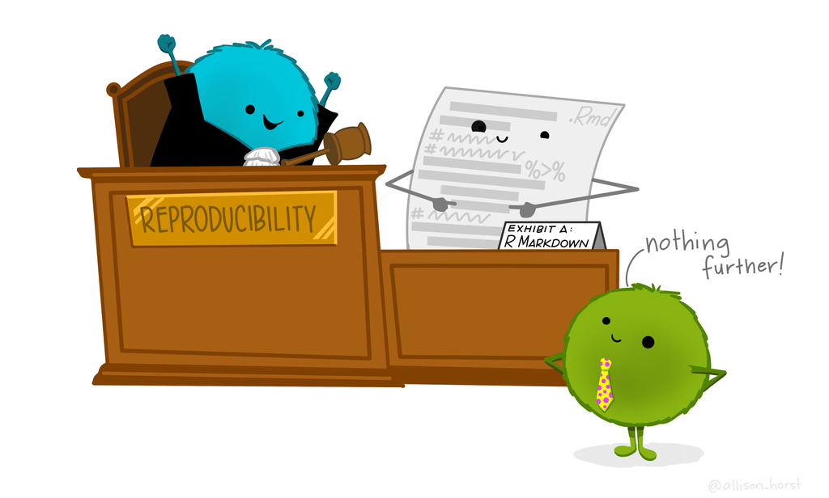

## Example: Finding Maternity Care Deserts

Consider what steps you would have to take if you wanted to see which parts of AZ do not have a hospital with an inpatient labor and delivery (L&D) unit within a 45-minute drive.

1. Obtain a list of hospitals with L&D.
2. Geocode hospital addresses.
3. Determine a 45-minute radius around each hospital with L&D.
4. Obtain AZ geographic boundaries.
5. Visualize the results.

## Set Up

| Package |  | Purpose |
| --- | --- | --- |
| jsonlite |  | Query CMS API to obtain data on hospitals |
| tidygeocoder |  | Geocode hospital addresses |
| dplyr |  | Wrangle data |
| stringr |  | Use text to filter data |
| tigris |  | Download Census Bureau TIGER/Line geographic boundaries |
| sf |  | Manipulate geosptial data |
| hereR |  | Query HERE API to determine 45-minute driving radius |
| mapview |  | Visualize geospatial data quickly |
| leaflet |  | Generate interactive geospatial visualizations |

To help query the HERE API, there is one user-defined tryLocation() function to source. This function is courtesy of [Hannah Recht](https://www.hrecht.com/r-drive-time-analysis-tutorial/tutorial.html).

*A [free API key](https://platform.here.com/access/) is required to use the {hereR} package.*

## Step 1

Obtain a list of AZ hospitals that reported maternal health data from the CMS [Provider Data Catalog](https://data.cms.gov/provider-data/dataset/nrdb-3fcy). Determine which hospitals do **not** have L&D units.

- Code
- Raw Hospital Results
- Hospitals without L&D

```r
# Query CMS Provider Data Catalog

query <- paste0(
  "https://data.cms.gov/provider-data/api/1/datastore/query/nrdb-3fcy/0",
  "?conditions[0][property]=State&conditions[0][value]=", params$state,
  "&conditions[0][operator]=="
)

raw <- jsonlite::fromJSON(query)

hospital_df <- raw$results

# Identify hospitals w/out L&D

no_inpatient <- hospital_df |>
  filter(stringr::str_detect(score, "does not provide inpatient labor")) |>
  distinct(facility_id, .keep_all = TRUE) |>
  select(c(facility_id, facility_name))

# Preview

head(hospital_df)

head(no_inpatient)
```

```
  facility_id                              facility_name
1       30002 BANNER - UNIVERSITY MEDICAL CENTER PHOENIX
2       30002 BANNER - UNIVERSITY MEDICAL CENTER PHOENIX
3       30002 BANNER - UNIVERSITY MEDICAL CENTER PHOENIX
4       30002 BANNER - UNIVERSITY MEDICAL CENTER PHOENIX
5       30002 BANNER - UNIVERSITY MEDICAL CENTER PHOENIX
6       30002 BANNER - UNIVERSITY MEDICAL CENTER PHOENIX
                  address citytown state zip_code countyparish telephone_number
1 1111 EAST MCDOWELL ROAD  PHOENIX    AZ    85006     MARICOPA   (602) 839-2000
2 1111 EAST MCDOWELL ROAD  PHOENIX    AZ    85006     MARICOPA   (602) 839-2000
3 1111 EAST MCDOWELL ROAD  PHOENIX    AZ    85006     MARICOPA   (602) 839-2000
4 1111 EAST MCDOWELL ROAD  PHOENIX    AZ    85006     MARICOPA   (602) 839-2000
5 1111 EAST MCDOWELL ROAD  PHOENIX    AZ    85006     MARICOPA   (602) 839-2000
6 1111 EAST MCDOWELL ROAD  PHOENIX    AZ    85006     MARICOPA   (602) 839-2000
  measure_id
```

[output cut: 20 more lines]

```
  facility_id                                facility_name
1       30010                          ST. MARY'S HOSPITAL
2       30014  HONOR HEALTH JOHN C. LINCOLN MEDICAL CENTER
3       30030                        ABRAZO CENTRAL CAMPUS
4       30037                      TEMPE ST LUKES HOSPITAL
5       30038 HONORHEALTH SCOTTSDALE OSBORN MEDICAL CENTER
6       30061                BANNER BOSWELL MEDICAL CENTER
```

*Check the [DKAN API documentation](https://dkan.readthedocs.io/en/latest/user-guide/guide_api.html) for filtering options.*

## Step 2

Geocode hospital addresses and turn into a geospatial dataset.

- Code
- Results

```r
# Filter and reformat hospital data

hospital_df <- hospital_df |>
  distinct(facility_id, .keep_all = TRUE) |>
  mutate(inpatient = case_when(facility_id %in% no_inpatient$facility_id  ~ "No",
                               .default = "Yes")) |>
  mutate(full_address = paste0(address, ", ", citytown, ", ", state, " ", zip_code),
         .after = zip_code) |>
  select(-c(telephone_number:end_date))

# Geocode hospital addresses

hospital_df <- hospital_df |>
  tidygeocoder::geocode(address = full_address, method = "arcgis")

# Convert to sf object

hospitals <- hospital_df |>
  st_as_sf(coords = c("long", "lat"),
           crs = 4326) # use {leaflet} preferred CRS

# Preview for quick QC

mapview::mapview(hospitals)
```

[interactive chart not shown]

## Step 3

Query the HERE API to determine a 45-minute driving radius (i.e., [isochrone](https://en.wikipedia.org/wiki/Isochrone_map)) around each hospital with L&D.

- Code
- Results

```r
# Set HERE API key

set_key(Sys.getenv("HERE_API_KEY"))

# Loop over point data to make isochrones file (using Hannah Recht's function)

## select hospitals w/ L&D

ip_hospitals <- hospitals |>
  filter(inpatient == "Yes")

## create empty vectors for loop output

isochrones <- vector(mode = "list", length = nrow(ip_hospitals))
error_rows <- vector(mode = "list", length = nrow(ip_hospitals))

for (i in 1:nrow(ip_hospitals)) {

    print(i)

    ## get isochrone for that point, using delay to avoid rate limiting
    Sys.sleep(0.9)

    ## filter to ith point
    point_temp <- ip_hospitals %>% filter(row_number() == i)
    point_id <- point_temp$facility_id

    isochrones_temp <- tryLocation(point_temp)

    ## save any errored out points
    if (is.null(isochrones_temp)) {
        error_rows <- bind_rows(error_rows, point_temp)
    } else {
        isochrones <- bind_rows(isochrones, isochrones_temp)
    }
}

# Remove extraneous columns

isochrones <- isochrones |>
  select(facility_id, geometry)

# Left join hospital data

ip_hospitals <- ip_hospitals |>
  select(c(facility_id, facility_name, full_address, inpatient)) |>
  st_drop_geometry()

isochrones <- isochrones |>
  left_join(ip_hospitals, by = join_by(facility_id))

# Reproject

isochrones <- isochrones |>
  st_transform(crs = 4326)

# Preview

mapview::mapview(isochrones)
```

If you want to try this out without signing up for a HERE API key, use the data available on [GitHub](https://github.com/toylyol/iarug-gis).

[interactive chart not shown]

*Store API key in [.Renviron file](https://laurenilano.com/posts/api-keys/) for ease and security.*

## Step 4

Obtain AZ county boundaries.

- Code
- Results

```r
# Download county boundaries

counties <- counties(state = c(params$state),
                     cb = TRUE,
                     resolution = "500k",
                     year = 2023)

# Reproject to {leaflet} preferred CRS

counties <- counties |>
  st_transform(crs = 4326)

# Create a quick QC viz

mapview::mapview(counties)
```

[interactive chart not shown]

## Step 5

Visualize the hospitals and isochrones in an interactive map.

- Code
- Results

```r
# Specify text for popups

hosp_popup <- paste0(
  hospitals$facility_name, " (",
  hospitals$full_address, ")"
)

iso_popup <- paste0(
  "This is a 45-minute driving radius around ",
  stringr::str_to_title(isochrones$facility_name), "."
)

# Create color palette

color_icon <- awesomeIcons(
  icon = 'location-pin',
  iconColor = ifelse(hospitals$inpatient == 'Yes', 'green', 'gray'),
  library = 'fa',
  markerColor =  ifelse(hospitals$inpatient == 'Yes', 'green', 'gray')) # no HEX codes

# Make an interactive map

leaflet() %>%
  addProviderTiles("CartoDB.Voyager") %>%    # add base map
  addPolygons(data = counties,
              weight = 1,
              color = "#999999",
              fillColor = "#d4d4d4",
              stroke = TRUE,
              popup = paste0(counties$NAME)) %>%
  addAwesomeMarkers(data = hospitals,
             icon = color_icon,
             group = hospitals$facility_name,
             popup = ~hosp_popup) %>%
  addPolygons(data = isochrones,
              weight = 1, opacity = 1.0,     # set stroke width and opacity
              stroke = TRUE,
              color = "#669933",
              fillColor = "#669933",
              fillOpacity = 0.5,
              group = isochrones$facility_name,
              popup = ~iso_popup,
              highlightOptions = highlightOptions(color = "#527c29",
                                                  weight = 3,
                                                  fill = TRUE,
                                                  fillColor = "#527c29",
                                                  fillOpacity = 0.75,
                                                  bringToFront = TRUE)
  ) %>%
  addLayersControl(
    overlayGroups = sort(c(isochrones$facility_name, hospitals$facility_name)),
    options = layersControlOptions(collapsed = TRUE)
  )
```

Use HTML to format text in a {leaflet} popup.

[interactive chart not shown]

## Possibilities

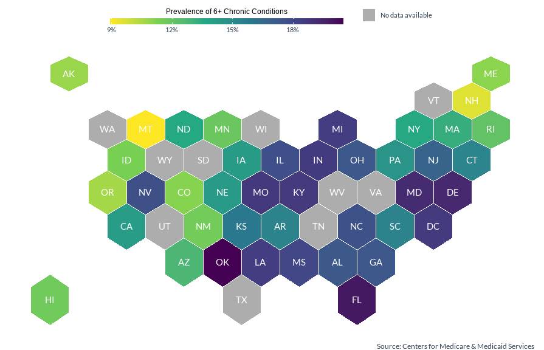

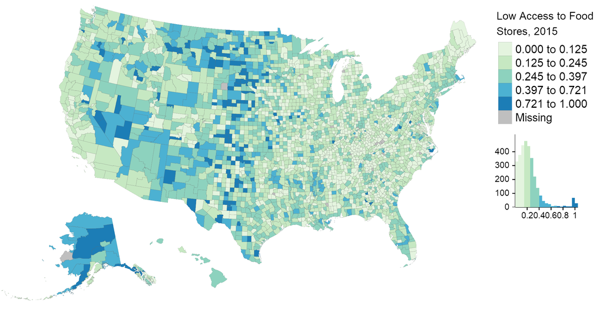

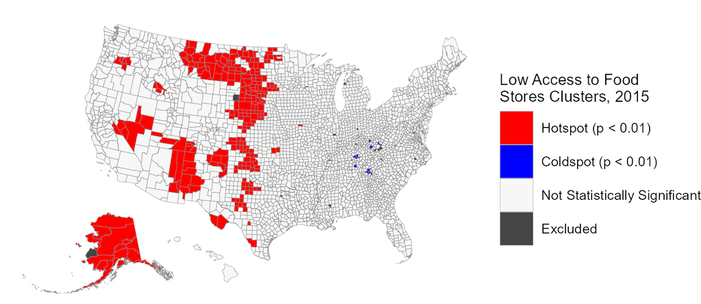

[figure not shown]

## Learn More

Here are some resources I have found helpful translating knowledge from a GIS like QGIS to R:

- [*Geocomputation with R*](https://r.geocompx.org/) (great to get a solid foundation)
- [Yan Holtz’ R Graph Gallery](https://r-graph-gallery.com/328-hexbin-map-of-the-usa.html) (many geosptial data viz tutorials are available, including the popular hexbin map)
- [R for the Rest of Us’ Mapping with R](https://rfortherestofus.com/courses/mapping/) (not free, but wonderful for learning many ways to visualize geospatial data in R)
- [*Analyzing US Census Data: Methods, Maps, and Models in R*](https://walker-data.com/census-r/spatial-analysis-with-us-census-data.html) (especially Chapter 7)
- [*Hands-On Spatial Data Science with R*](https://spatialanalysis.github.io/handsonspatialdata/index.html) (great for GeoDa users)
- [UChicago Center for Spatial Data Science Tutorials](https://spatialanalysis.github.io/tutorials/) (also great for GeoDa users)
- [Josiah Perry’s Hot Spot Analysis Tutorial](https://www.youtube.com/watch?v=OnMNZwJywjs) (a helpful overview of the underlying spatial statistics, even if you don’t use the {sfdep} package)